# Physical health-related quality of life (SF-12 PCS) in adults with chronic disease

Dataset 8: Patient activation for self-management in chronic disease

RSR feasibility analysis

2026-08-03

# Introduction

Physical health-related quality of life is the outcome patients themselves care most about in long-term illness, and it is only loosely tied to clinical severity markers. These data come from a cross-sectional survey of 1,154 Dutch adults treated in primary and secondary care for type 2 diabetes, COPD, chronic heart failure or chronic renal disease (Bos-Touwen et al., *PLoS ONE* 2015;10(5):e0126400), in which the SF-12 was administered alongside demographic, anthropometric and illness-belief measures. Understanding which patient characteristics track physical functioning across four different conditions helps distinguish disease-specific from generic drivers of disability.

**Aim.** Among Dutch adults with one of four chronic conditions, we examined which of age, sex, body mass index, smoking status, index disease, comorbidity burden and illness perceptions are independently associated with the SF-12 physical component score, mutually adjusting for the others.

This is a *Purpose 3* analysis: several predictors are of interest and the question is which remain associated with the outcome after mutual adjustment.

# Methods

**Data source.** Cross-sectional survey of adults with type 2 diabetes, COPD, chronic heart failure or chronic renal disease recruited from Dutch general practices and hospital outpatient clinics; 1154 participants, all measured on a single occasion.

**Variables.** The outcome is `sf12_physical`, the SF-12 physical component score on a 0-100 scale, where higher means better physical health. Predictors are `age_yrs` (years), `sex` (reference: male), `bmi` (kg/m²), `smoking_status` (never / former / current, reference: never — the clinically unexposed group), `disease` (reference: type 2 diabetes, the largest group), `charlson_index` (points; higher = more comorbidity) and `ipq_total` (Brief Illness Perception Questionnaire total, 0-80; higher = a more threatening view of one’s illness).

**Body size.** In this file `bmi` is exactly `weight_kg / (height_cm/100)^2`, so `bmi`, `height_cm` and `weight_kg` can never all appear in the same model. Only `bmi` is used.

**Sibling scale deliberately excluded.** `sf12_mental` is the other component of the same 12-item instrument, computed from overlapping items and completed at the same sitting; it correlates 0.75 with the outcome. Its variance-inflation factor if entered would be only 1.55, so collinearity is not the reason to leave it out — the reason is that adjusted R² would rise from 0.43 to 0.65 and the model would largely be the SF-12 predicting itself, which is a restatement of the outcome rather than an explanation. It is therefore excluded. `n_comorbidities` correlates 0.78 with `charlson_index`, so only the Charlson index is used.

**Statistical analysis.** Linear regression (`lm()`), justified because the outcome is a continuous 0-100 score. We fitted a univariable model for each predictor first, then a single multivariable model containing all of them. Predictors were chosen in advance on subject-matter grounds, not by significance. Significance threshold 0.05; estimates are reported with 95% confidence intervals. Assumptions were checked with `performance::check_model()`. Analysis used R version 4.6.0 (2026-04-24) with tidyverse, gtsummary and performance.

**Missing data.** Complete-case analysis: 1078 of 1154 rows were analysed (76 dropped). Missing questionnaire answers were coded 99 in the original deposit, but that conversion to `NA` has already been applied in this CSV; a check across all numeric columns other than `id` found 0 remaining values equal to 99, so no further re-coding was needed.

# Results

## Sample characteristics

**Table 1. Sample characteristics.**

| **Characteristic** | **N** | **N = 1,078**<sup>1</sup> |
| --- | --- | --- |
| sf12_physical | 1,078 | 50 (31, 75) |
| age_yrs | 1,078 | 70 (62, 77) |
| sex | 1,078 |  |
| Male |  | 658 (61%) |
| Female |  | 420 (39%) |
| bmi | 1,078 | 27.0 (24.5, 30.1) |
| smoking_status | 1,078 |  |
| Never |  | 260 (24%) |
| Former |  | 628 (58%) |
| Current |  | 190 (18%) |
| disease | 1,078 |  |
| Type 2 diabetes |  | 403 (37%) |
| COPD |  | 274 (25%) |
| Heart failure |  | 201 (19%) |
| Renal disease |  | 200 (19%) |
| charlson_index | 1,078 | 2.50 (1.00, 4.00) |
| ipq_total | 1,078 | 37 (27, 45) |

<sup>1</sup> Median (Q1, Q3); n (%)

## Exploratory figure

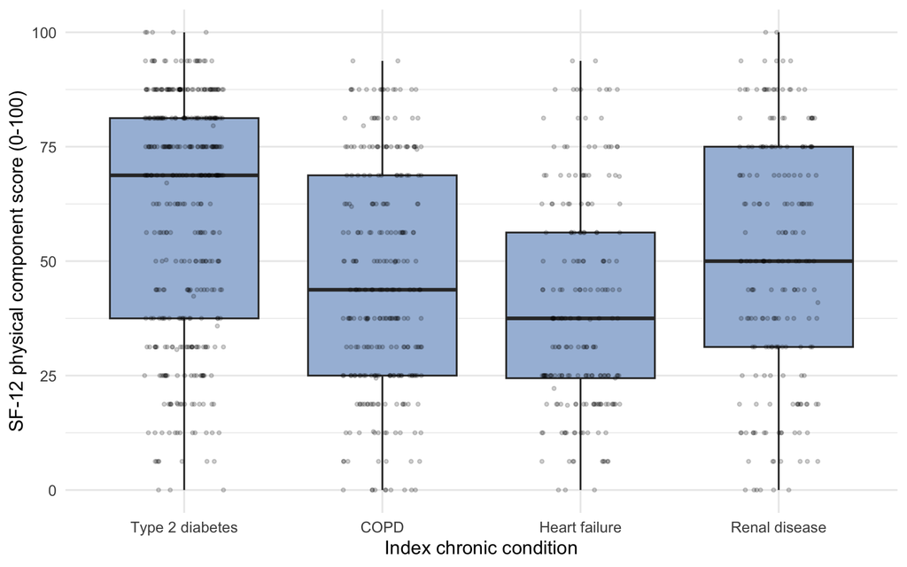

Figure 1. SF-12 physical component score by index disease. Boxes show medians and interquartile ranges; points are individual participants.

Physical functioning differs markedly between the four pooled disease groups: heart failure and COPD patients sit roughly 15-20 points below the diabetes group, with renal disease in between — differences far larger than anything the demographic variables produce.

## Univariable models

| **Characteristic** | **N** | **Beta** | **95% CI** | **p-value** |
| --- | --- | --- | --- | --- |
| age_yrs | 1,078 | -0.54 | -0.68, -0.40 | <0.001 |
| sex | 1,078 |  |  |  |
| Male |  | — | — |  |
| Female |  | -7.5 | -11, -4.3 | <0.001 |
| bmi | 1,078 | -0.66 | -1.0, -0.31 | <0.001 |
| smoking_status | 1,078 |  |  |  |
| Never |  | — | — |  |
| Former |  | 0.93 | -2.9, 4.8 | 0.6 |
| Current |  | 1.2 | -3.8, 6.1 | 0.6 |
| disease | 1,078 |  |  |  |
| Type 2 diabetes |  | — | — |  |
| COPD |  | -15 | -19, -11 | <0.001 |
| Heart failure |  | -21 | -25, -17 | <0.001 |
| Renal disease |  | -11 | -15, -6.3 | <0.001 |
| charlson_index | 1,078 | -5.1 | -5.9, -4.3 | <0.001 |
| ipq_total | 1,078 | -1.1 | -1.2, -0.99 | <0.001 |

Abbreviation: CI = Confidence Interval

Illness perception is the strongest continuous crude predictor: each additional IPQ point is associated with a 1.10-point lower SF-12 physical score (95% CI -1.21 to -0.99, p < 0.001), so patients at the top and bottom of the IPQ range differ by tens of points on the SF-12. Comorbidity burden is also strong (-5.12 per Charlson point, 95% CI -5.92 to -4.31, p < 0.001), as is age (-0.54 per year, 95% CI -0.68 to -0.40) and female sex (-7.51, 95% CI -10.72 to -4.30). BMI is modestly associated (-0.66 per kg/m², 95% CI -1.01 to -0.31, p < 0.001). Crudely, heart failure patients score 20.8 points and COPD patients 15.3 points below the diabetes group (both p < 0.001). Smoking status shows no crude association at all (both contrasts p > 0.6).

## Why adjustment is needed

The crude disease differences in Figure 1 are the clearest case for adjustment in this dataset. `charlson_index` is a confounder of them: the heart-failure and renal groups carry substantially more comorbidity than the diabetes group, and comorbidity independently predicts worse physical functioning, so a large part of the apparent “heart failure effect” is really the extra disease those patients carry. `age_yrs` works the same way — the heart-failure and renal groups are older, and age independently predicts worse physical function. `ipq_total` is a third: patients with the more disabling conditions also hold more threatening illness beliefs, and illness beliefs are themselves associated with reported functioning, so the crude disease contrasts partly reflect differences in how patients construe their illness. Because the four groups were pooled by design, `disease` has to be in the model both as an adjustment variable for the other predictors and as a comparison of interest in its own right.

## Multivariable model

| **Characteristic** | **Beta** | **95% CI** | **p-value** |
| --- | --- | --- | --- |
| age_yrs | -0.40 | -0.52, -0.28 | <0.001 |
| sex |  |  |  |
| Male | — | — |  |
| Female | -7.9 | -10, -5.3 | <0.001 |
| bmi | -0.86 | -1.1, -0.59 | <0.001 |
| smoking_status |  |  |  |
| Never | — | — |  |
| Former | 1.0 | -2.0, 4.1 | 0.5 |
| Current | 0.49 | -3.5, 4.5 | 0.8 |
| disease |  |  |  |
| Type 2 diabetes | — | — |  |
| COPD | -7.4 | -11, -4.0 | <0.001 |
| Heart failure | -4.9 | -8.7, -1.1 | 0.012 |
| Renal disease | 3.8 | -0.01, 7.6 | 0.051 |
| charlson_index | -3.7 | -4.5, -2.9 | <0.001 |
| ipq_total | -0.94 | -1.0, -0.83 | <0.001 |

Abbreviation: CI = Confidence Interval

Model fit

| Statistic | Value |
| --- | --- |
| R-squared | 0.431 |
| Adjusted R-squared | 0.426 |
| Residual SE | 20.020 |
| N | 1078.000 |
| Model df | 10.000 |

Conditional on all other predictors, each IPQ point is associated with a 0.94-point lower SF-12 physical score (95% CI -1.04 to -0.83, p < 0.001) and each Charlson point with a 3.72-point lower score (95% CI -4.49 to -2.94, p < 0.001). Age remains associated (-0.40 per year, 95% CI -0.52 to -0.28), as does female sex (-7.87, 95% CI -10.42 to -5.33) and BMI (-0.86 per kg/m², 95% CI -1.13 to -0.59, p < 0.001) — note that the BMI association *strengthens* after adjustment. COPD (-7.39, 95% CI -10.77 to -4.02) and heart failure (-4.87, 95% CI -8.65 to -1.08, p = 0.012) remain below diabetes; renal disease now sits 3.78 points *above* diabetes, at the edge of significance (95% CI -0.01 to 7.57, p = 0.051). Smoking status is not associated in either the crude or the adjusted model. The model explains R² = 0.431 of the variance (adjusted R² = 0.426), much the best fit of the five outcomes in this dataset.

## Unadjusted versus adjusted

**Table 2. Unadjusted and adjusted estimates.**

| **Characteristic** | **Unadjusted** **N** | **Unadjusted** **Beta** | **Unadjusted** **95% CI** | **Unadjusted** **p-value** | **Adjusted** **Beta** | **Adjusted** **95% CI** | **Adjusted** **p-value** |
| --- | --- | --- | --- | --- | --- | --- | --- |
| age_yrs | 1,078 | -0.54 | -0.68, -0.40 | <0.001 | -0.40 | -0.52, -0.28 | <0.001 |
| sex | 1,078 |  |  |  |  |  |  |
| Male |  | — | — |  | — | — |  |
| Female |  | -7.5 | -11, -4.3 | <0.001 | -7.9 | -10, -5.3 | <0.001 |
| bmi | 1,078 | -0.66 | -1.0, -0.31 | <0.001 | -0.86 | -1.1, -0.59 | <0.001 |
| smoking_status | 1,078 |  |  |  |  |  |  |
| Never |  | — | — |  | — | — |  |
| Former |  | 0.93 | -2.9, 4.8 | 0.6 | 1.0 | -2.0, 4.1 | 0.5 |
| Current |  | 1.2 | -3.8, 6.1 | 0.6 | 0.49 | -3.5, 4.5 | 0.8 |
| disease | 1,078 |  |  |  |  |  |  |
| Type 2 diabetes |  | — | — |  | — | — |  |
| COPD |  | -15 | -19, -11 | <0.001 | -7.4 | -11, -4.0 | <0.001 |
| Heart failure |  | -21 | -25, -17 | <0.001 | -4.9 | -8.7, -1.1 | 0.012 |
| Renal disease |  | -11 | -15, -6.3 | <0.001 | 3.8 | -0.01, 7.6 | 0.051 |
| charlson_index | 1,078 | -5.1 | -5.9, -4.3 | <0.001 | -3.7 | -4.5, -2.9 | <0.001 |
| ipq_total | 1,078 | -1.1 | -1.2, -0.99 | <0.001 | -0.94 | -1.0, -0.83 | <0.001 |

Abbreviation: CI = Confidence Interval

The disease coefficients move enormously towards the null. Heart failure goes from -20.8 to -4.9 and COPD from -15.3 to -7.4, so roughly three-quarters and one-half of those crude deficits respectively are explained by age, comorbidity and illness perceptions rather than the diagnosis itself. Renal disease does more than attenuate — it crosses the null, from -10.6 crude to +3.8 adjusted: once you compare renal patients with diabetes patients of the same age and comorbidity burden and the same illness beliefs, the renal patients report slightly *better* physical function. That sign reversal is the single most striking result in this analysis and should be reported cautiously, because it depends heavily on the Charlson index doing the work that a disease-specific severity marker (eGFR, dialysis status) should be doing. The Charlson index itself attenuates from -5.12 to -3.72 and age from -0.54 to -0.40, both by sharing explanatory work with each other and with `disease`. Two predictors barely move: female sex (-7.51 to -7.87) and, in the other direction, BMI strengthens from -0.66 to -0.86 — negative confounding, because BMI is inversely related to age in this sample (r = -0.13) and older age also lowers the SF-12. No predictor changes significance status except renal disease, which moves from clearly significant and negative to borderline and positive. All VIFs are below 1.7, so none of this is collinearity.

## Diagnostics

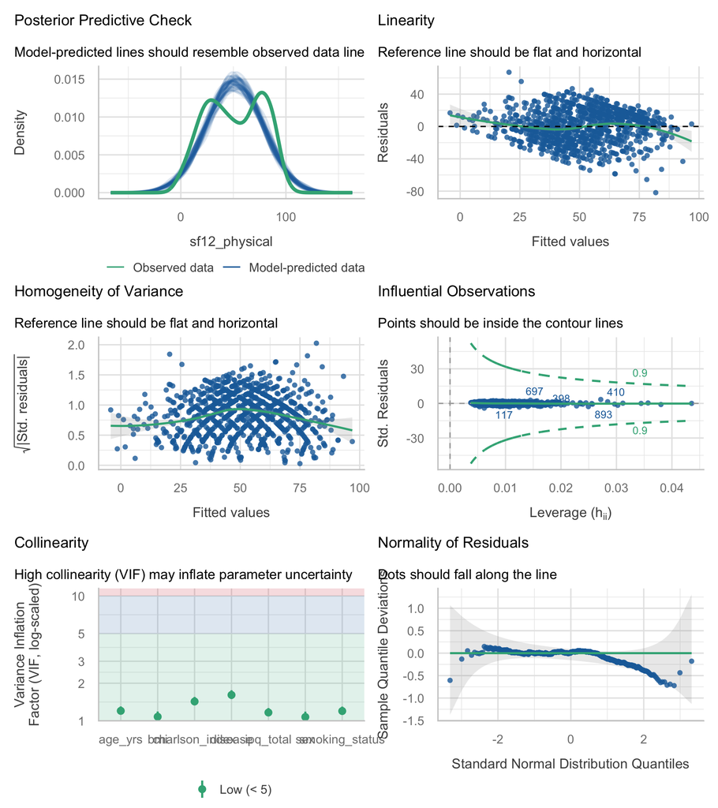

```
## OK: Error variance appears to be homoscedastic (p = 0.290).
```

| Term | VIF | VIF_CI_low | VIF_CI_high | SE_factor | Tolerance | Tolerance_CI_low | Tolerance_CI_high |
| --- | --- | --- | --- | --- | --- | --- | --- |
| age_yrs | 1.201915 | 1.134021 | 1.304202 | 1.096319 | 0.8320058 | 0.7667525 | 0.8818175 |
| sex | 1.073003 | 1.028937 | 1.184174 | 1.035859 | 0.9319634 | 0.8444704 | 0.9718765 |
| bmi | 1.078216 | 1.032717 | 1.186986 | 1.038372 | 0.9274581 | 0.8424696 | 0.9683191 |
| smoking_status | 1.197559 | 1.130289 | 1.299561 | 1.046102 | 0.8350321 | 0.7694905 | 0.8847296 |
| disease | 1.611250 | 1.493326 | 1.757363 | 1.082747 | 0.6206361 | 0.5690343 | 0.6696463 |
| charlson_index | 1.428783 | 1.332146 | 1.553536 | 1.195317 | 0.6998964 | 0.6436928 | 0.7506685 |
| ipq_total | 1.165693 | 1.103180 | 1.266082 | 1.079673 | 0.8578585 | 0.7898380 | 0.9064706 |

Linearity is acceptable and the reference-line smooth in the residual plot is close to flat. Homogeneity of variance passes (`check_heteroscedasticity()` p = 0.290), so ordinary standard errors are reported and HC3 robust re-estimation was not required. Normality of residuals is formally rejected (p < 0.001): the SF-12 physical score in this file takes only 39 distinct values because it is a coarse sum of a small number of items, so the residual distribution is visibly lumpy, and the posterior-predictive check shows the model producing a smoother distribution than the data actually has. With n = 1078 this has little effect on the confidence intervals, but it is a real mismatch between an interval-scale model and an ordinal-scale instrument. Collinearity is fine: the largest VIF is `disease` at 1.61, then `charlson_index` at 1.43. No observation exceeds the Cook’s distance threshold.

# Discussion

Among Dutch adults with one of four chronic conditions, comorbidity burden and threatening illness beliefs are the characteristics most strongly and independently associated with physical health-related quality of life, followed by age, female sex and higher BMI. Once these are held constant, the large raw gaps between the four disease groups shrink by half or more, and the renal group’s apparent disadvantage disappears entirely. Practically, this says that in a mixed chronic-disease clinic, how many other conditions a patient has and how they think about their illness tell you more about their physical functioning than which diagnosis is written at the top of their chart.

**Limitations.** The design is cross-sectional, so the illness-perception association could run in either direction — patients who function badly may reasonably come to see their illness as more threatening. IPQ and SF-12 are both self-reported on the same occasion, so common-method bias inflates that association. Most importantly, the file contains **no disease-specific severity markers**: there is no eGFR or dialysis status for the renal group, no NYHA class for heart failure and no GOLD stage for COPD. The `disease` coefficients after adjustment therefore rest entirely on the generic Charlson index as a severity proxy, and the renal-disease sign reversal in particular is very likely an artefact of unmeasured severity rather than a real advantage. The SF-12 takes only 39 distinct values here, so treating it as continuous is an approximation and residual normality fails. Complete-case analysis dropped 76 participants (6.6%). All estimates are associations, not effects.

**Future work.** Linking these survey data to disease-specific severity measures would show how much of the residual between-disease difference is severity and how much is the condition itself.

# Feasibility notes

*Not part of a student report.*

- **Best-fitting of the five outcomes.** R² = 0.431, adjusted R² = 0.426, with several large, clearly significant coefficients. Students get a satisfying model.
- **Complete-case N = 1078** of 1154 (76 dropped, 6.6%).
- **No collinearity problem**: max VIF 1.61 (`disease`). But the sibling trap is live — `sf12_mental` has VIF 1.55, i.e. it looks harmless on a VIF check, yet adding it takes adjusted R² from 0.426 to 0.650. A student who includes it will conclude that “mental health is the strongest predictor of physical health” when they have really fitted the SF-12 to itself. This must be ruled out in the brief.
- **`bmi` = `weight_kg`/(`height_cm`/100)² exactly** in this file. Putting all three in one model gives a rank-deficient / near-singular fit. Only `bmi` is used here.
- **Diagnostics**: homoscedasticity passes (p = 0.29), so no HC3 needed. Normality is rejected, driven by the SF-12 having only 39 achievable values — worth showing students the posterior-predictive panel for this.
- **The renal-disease sign reversal** (crude -10.6 to adjusted +3.8) is interesting but is almost certainly residual confounding by unmeasured renal severity. Strong students can discuss it; weak students will report it as a finding.
- **`smoking_status` is a dud predictor** (crude and adjusted p > 0.5). Useful as an honest “not everything is significant” example, but a student hoping for a smoking result will be disappointed.